**Note** : Due to the length of some processes, we have made the notification setting using the win10toast library for windows to inform the computer. please make the necessary operations If your computer's operating system is not Windows 10.

[figure not shown]

You can access the presentation of the project from the link. https://prezi.com/view/YKUlBDLQSaheIAyLOwzh/

# Plan

1. Defining the data set
2. Obtaining basic information about the data set
3. Basic operations on data set (tokenization, stemming, lemmatization, pos, chunking, ...)
4. Mathematical Operations and Simple Feature Extraction
5. Wordcloud
6. Comparing Algorithms (Count Vector, Word Level/Char Level/N-Gram TF-IDF)
7. Comparing ML Algorithms
8. Determining the most successful ML algorithm and training with it
9. After the training, processing on the test data
10. Finding the most successful model for Toxicty prediction (Decision Trees vs Neural Network)
11. Using the most successful method for toxicity estimation

# 1. Dataset

```python
import pandas as pd
import numpy as np
import matplotlib.pyplot as plt
import seaborn as sns
import time
from win10toast import ToastNotifier
```

```python
toaster  = ToastNotifier()
```

```python
train = pd.read_csv('train_preprocessed.csv')
test = pd.read_csv('test_preprocessed.csv')
train_df = train.copy()
test_df = test.copy()
```

```python
train_df.info()
```

```
<class 'pandas.core.frame.DataFrame'>
RangeIndex: 159571 entries, 0 to 159570
Data columns (total 10 columns):
 #   Column         Non-Null Count   Dtype
---  ------         --------------   -----
 0   comment_text   159571 non-null  object
 1   id             159571 non-null  object
 2   identity_hate  159571 non-null  float64
 3   insult         159571 non-null  float64
 4   obscene        159571 non-null  float64
 5   set            159571 non-null  object
 6   severe_toxic   159571 non-null  float64
 7   threat         159571 non-null  float64
 8   toxic          159571 non-null  float64
 9   toxicity       159571 non-null  float64
dtypes: float64(7), object(3)
memory usage: 12.2+ MB
```

```python
nrow_train=train_df.shape[0]
nrow_test=test_df.shape[0]
sum=nrow_train+nrow_test
print("       : train : test")
print("rows   :",nrow_train,":",nrow_test)
print("perc   :",round(nrow_train*100/sum),"   :",round(nrow_test*100/sum))
```

```
       : train : test
rows   : 159571 : 153164
perc   : 51    : 49
```

## 1.1 Distribution of variables on categorical basis

```python
# dropping id, set,toxicity and comment text
df_cat = train_df.drop(['id','set','toxicity', 'comment_text'], axis=1)
# calculating total count of each category comments
counts = []
categories = list(df_cat.columns.values)
for i in categories:
    counts.append((i, df_cat[i].sum()))
df_stats = pd.DataFrame(counts, columns=['category', 'count'])
df_stats
```

|  | category | count |
| --- | --- | --- |
| 0 | identity_hate | 1405.0 |
| 1 | insult | 7877.0 |
| 2 | obscene | 8449.0 |
| 3 | severe_toxic | 1595.0 |
| 4 | threat | 478.0 |
| 5 | toxic | 15294.0 |

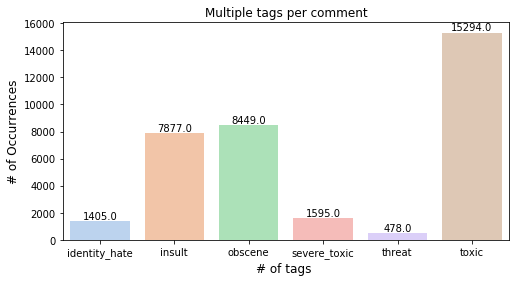

```python
rowsums = df_cat.iloc[:,:].sum(axis=1)

#plot
plt.figure(figsize=(8,4))
ax = sns.barplot(x.index, x.values, alpha=0.8,palette="pastel")
plt.title("Multiple tags per comment")
plt.ylabel('# of Occurrences', fontsize=12)
plt.xlabel('# of tags ', fontsize=12)

#adding the text labels
rects = ax.patches
labels = x.values
for rect, label in zip(rects, labels):
    height = rect.get_height()
    ax.text(rect.get_x() + rect.get_width()/2, height + 5, label, ha='center', va='bottom')

plt.show()
```

**This shows that the number of comments in each category is extremely unstable.**

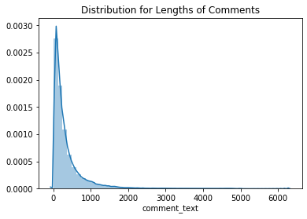

```python
lens = train_df.comment_text.str.len()
sns.distplot(lens)
plt.title("Distribution for Lengths of Comments")
plt.show()
```

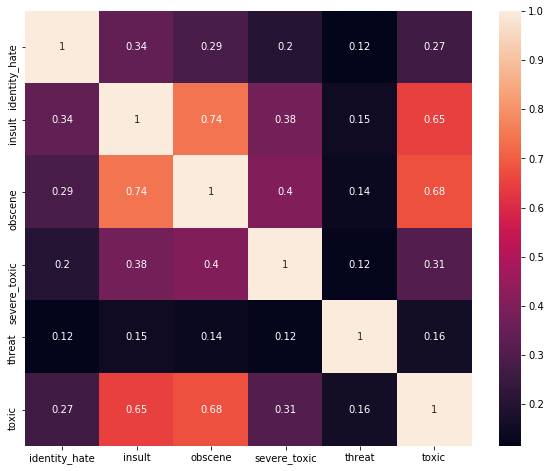

```python
temp_df=train_df.iloc[:,2:-1]

corr=temp_df.corr()
plt.figure(figsize=(10,8))
sns.heatmap(corr,
            xticklabels=corr.columns.values,
            yticklabels=corr.columns.values, annot=True);
```

```python
x=train_df.iloc[:,1:].sum()

# mark comments without any tags as "clean"
train_df['clean']=(rowsums==0)
#count number of clean entries
train_df['clean'].sum()
print("Total comments = ",len(train_df))
print("Total clean comments = ",train_df['clean'].sum())
```

```
Total comments =  159571
Total clean comments =  143346
```

## 1.2 Process

In these steps, we chose to use nltk instead of spacy because nltk gave better results when we compared the time.

```python
columns = ["comment_text","identity_hate", "insult", "obscene", "severe_toxic","threat", "toxic"]

d_mdf = train[columns]
```

```python
# if we have a capital letter
d_mdf = d_mdf["comment_text"].apply(lambda x: " ".join(x.lower() for x in x.split()))
print(d_mdf.head(5))
print(type(d_mdf))
```

```
0    explanation why the edits made under my userna...
1    d aww he matches this background colour i m se...
2    hey man i m really not trying to edit war it s...
3    more i can t make any real suggestions on impr...
4    you sir are my hero any chance you remember wh...
Name: comment_text, dtype: object
<class 'pandas.core.series.Series'>
```

```python
# if there are punctuation marks, their deletion
d_mdf = d_mdf.str.replace("[^\w\s]", "")
d_mdf
```

```
0         explanation why the edits made under my userna...
1         d aww he matches this background colour i m se...
2         hey man i m really not trying to edit war it s...
3         more i can t make any real suggestions on impr...
4         you sir are my hero any chance you remember wh...
                                ...
159566    and for the second time of asking when your vi...
159567    you should be ashamed of yourself that is a ho...
159568    spitzer umm theres no actual article for prost...
159569    and it looks like it was actually you who put ...
159570    and i really don t think you understand i came...
Name: comment_text, Length: 159571, dtype: object
```

```python
# Deleting numbers
d_mdf = d_mdf.str.replace("\d", "")
d_mdf = pd.DataFrame(d_mdf, columns = ["comment_text"])
d_mdf
```

|  | comment_text |
| --- | --- |
| 0 | explanation why the edits made under my userna... |
| 1 | d aww he matches this background colour i m se... |
| 2 | hey man i m really not trying to edit war it s... |
| 3 | more i can t make any real suggestions on impr... |
| 4 | you sir are my hero any chance you remember wh... |
| ... | ... |
| 159566 | and for the second time of asking when your vi... |
| 159567 | you should be ashamed of yourself that is a ho... |
| 159568 | spitzer umm theres no actual article for prost... |
| 159569 | and it looks like it was actually you who put ... |
| 159570 | and i really don t think you understand i came... |

159571 rows × 1 columns

```python
# Removal of Stopwords
import nltk
from nltk.corpus import stopwords
nltk.download("stopwords")
```

```
True
```

```python
sw = stopwords.words("english")
```

```python
# There are many meaningful or meaningless words not included in stopwords in our dataset.
# We tried to add the ones that catch our eyes to the sw list.
other_stop = ["d","ur","ah","la","hi","aww","lol","ah","ahh","alll","tã","l","c","i","eh","fr","e","no","s","o","a","u","so", "b","ü","nah", "n","s","nd","v",
             "th","alll","boo","bo","mmm","umm"]
sw = sw + other_stop
```

```python
d_mdf = d_mdf["comment_text"].apply(lambda x: " ".join(x for x in x.split() if x not in sw))
d_mdf.head()
```

```
0    explanation edits made username hardcore metal...
1    matches background colour seemingly stuck than...
2    hey man really trying edit war guy constantly ...
3    make real suggestions improvement wondered sec...
4                        sir hero chance remember page
Name: comment_text, dtype: object
```

```python
# Deleting less frequently words
d_mdf = pd.DataFrame(d_mdf, columns = ["comment_text"])
pd.Series(" ".join(d_mdf["comment_text"]).split()).value_counts()
```

```
article      57738
wikipedia    48534
page         46542
talk         37908
please       29815
             ...
tournai          1
libility         1
stimpy           1
amusment         1
eos              1
Length: 166754, dtype: int64
```

```python
count_ = pd.Series(" ".join(d_mdf["comment_text"]).split()).value_counts()
count_ = pd.DataFrame(count_, columns = ["num"])
count_[count_['num'] < 5].count()
```

```
num    125675
dtype: int64
```

```python
del_ = pd.Series(" ".join(d_mdf["comment_text"]).split()).value_counts()[-125675:]
```

```python
d_mdf["comment_text"].apply(lambda x: " ".join(x for x in x.split() if x not in del_))
```

```
0         explanation edits made username hardcore metal...
1         matches background colour seemingly stuck than...
2         hey man really trying edit war guy constantly ...
3         make real suggestions improvement wondered sec...
4                             sir hero chance remember page
                                ...
159566    second time asking view completely contradicts...
159567                 ashamed horrible thing put talk page
159568    spitzer theres actual article prostitution rin...
159569    looks like actually put speedy first version d...
159570    really think understand came idea bad right aw...
Name: comment_text, Length: 159571, dtype: object
```

### 1.2.1 Tokenization

```python
nltk.download("punkt")
import textblob
from textblob import TextBlob
```

```python
TextBlob(d_mdf["comment_text"][1]).words
```

```
WordList(['matches', 'background', 'colour', 'seemingly', 'stuck', 'thanks', 'talk', 'january', 'utc'])
```

```python
start = time.time()
d_mdf["comment_text"].apply(lambda x: TextBlob(x).words)
duration_ = time.time() - start
toaster.show_toast("Tokenization with TextBlob is completed",
                   f"Duration : {duration_}", duration = 5)
```

```
True
```

```python
d_mdf.head()
```

|  | comment_text |
| --- | --- |
| 0 | explanation edits made username hardcore metal... |
| 1 | matches background colour seemingly stuck than... |
| 2 | hey man really trying edit war guy constantly ... |
| 3 | make real suggestions improvement wondered sec... |
| 4 | sir hero chance remember page |

### 1.2.2 Stemming

```python
from nltk.stem import PorterStemmer
st = PorterStemmer()
```

```python
start = time.time()
d_mdf["comment_text"].apply(lambda x: " ".join([st.stem(x) for x in x.split()]))
duration_ = time.time() - start
toaster.show_toast("Stemming with nltk-PorterStemmer is completed",
                   f"Duration : {duration_}", duration = 5)
print(f"Stemming with nltk duration  :{duration_}")
```

```
Stemming with nltk duration  :92.340491771698
```

### 1.2.3 Lemmatization

```python
from textblob import Word
nltk.download("wordnet")
```

```
True
```

```python
d_mdf = pd.DataFrame(d_mdf, columns = ["comment_text"])
start = time.time()
d_mdf = d_mdf["comment_text"].apply(lambda x: " ".join([Word(x).lemmatize() for x in x.split()]))
duration_ = time.time() - start
toaster.show_toast("Lemmatization with textblob's word  is completed",
                  f"Duration : {duration_}", duration = 5)
print(f"Lemmmatization with textblob duration  :{duration_}")
d_mdf = pd.DataFrame(d_mdf, columns = ["comment_text"])
```

```
Lemmmatization with textblob duration  :26.64755082130432
```

```python
# compare last form

a = d_mdf["comment_text"][:5]
b = train["comment_text"][:5]
last = pd.concat([a, b], axis = 1)
last
```

|  | comment_text | comment_text |
| --- | --- | --- |
| 0 | explanation edits made username hardcore metal... | explanation why the edits made under my userna... |
| 1 | match background colour seemingly stuck thanks... | d aww he matches this background colour i m s... |
| 2 | hey man really trying edit war guy constantly ... | hey man i m really not trying to edit war it... |
| 3 | make real suggestion improvement wondered sect... | more i can t make any real suggestions on im... |
| 4 | sir hero chance remember page | you sir are my hero any chance you remember... |

### 1.2.4 POS

```python
nltk.download("averaged_perceptron_tagger")
```

```
True
```

```python
# TextBlob(d_mdf["comment_text"][2]).tags
start = time.time()
d_mdf["comment_text"].apply(lambda x: TextBlob(x).tags)
duration_ = time.time() - start
toaster.show_toast("POS with nltk is completed",
                   f"Duration : {duration_}", duration = 10)
print("POS with nltk duration : ", duration_)
```

```
POS with nltk duration :  384.40153217315674
```

### 1.2.5 Chunking (Shallow Parsing)

```python
pos = d_mdf["comment_text"].apply(lambda x: TextBlob(x).tags)
```

```python
## https://pythonprogramming.net/natural-language-toolkit-nltk-part-speech-tagging/
reg_exp = "NP: {<RB.?>*<VB.?>*<NNP>}"
rp = nltk.RegexpParser(reg_exp)
```

```python
results_ = rp.parse(pos[0])
print(results_)
```

```
(S
  explanation/NN
  edits/NNS
  made/VBN
  username/JJ
  hardcore/NN
  metallica/NN
  fan/NN
  reverted/VBD
  vandalism/NN
  closure/NN
  gas/NN
  voted/VBD
  new/JJ
  york/NN
  doll/NN
  fac/JJ
  please/NN
  remove/VB
  template/NN
  talk/NN
  page/NN
  since/IN
  retired/VBN)
```

```python
results_.draw() # Output in a separate window
```

### 1.2.6 Named Entity Recognition

```python
from nltk import  ne_chunk
nltk.download("maxent_ne_chunker")
nltk.download("words")
```

```
True
```

```python
print(ne_chunk(pos[0]))
```

```
(S
  explanation/NN
  edits/NNS
  made/VBN
  username/JJ
  hardcore/NN
  metallica/NN
  fan/NN
  reverted/VBD
  vandalism/NN
  closure/NN
  gas/NN
  voted/VBD
  new/JJ
  york/NN
  doll/NN
  fac/JJ
  please/NN
  remove/VB
  template/NN
  talk/NN
  page/NN
  since/IN
  retired/VBN)
```

### 1.2.7 Visualizing Named Entities

```python
# Perform standard imports
import spacy
nlp = spacy.load('en_core_web_sm')

# Import the displaCy library
from spacy import displacy
```

```python
b[4]
```

```
'you  sir  are my hero  any chance you remember what page that s on '
```

```python
doc = nlp(b[1])
displacy.render(doc, style='ent', jupyter=True)
```

d aww he matches this background colour i m seemingly stuck with thanks talk january DATE utc

### 1.3 Mathematical Operations and Simple Feature Extraction

### 1.3.1 Number of Letters / Characters

```python
o_df = d_mdf.copy()
o_df["comment_text"].head()
```

```
0    explanation edits made username hardcore metal...
1    match background colour seemingly stuck thanks...
2    hey man really trying edit war guy constantly ...
3    make real suggestion improvement wondered sect...
4                        sir hero chance remember page
Name: comment_text, dtype: object
```

```python
o_df["comment_text"].str.len()
```

```
0         156
1          63
2         141
3         365
4          29
         ...
159566    178
159567     36
159568     61
159569     56
159570    107
Name: comment_text, Length: 159571, dtype: int64
```

```python
o_df["num_letter"] = o_df["comment_text"].str.len()
```

```python
o_df
```

|  | comment_text | num_letter |
| --- | --- | --- |
| 0 | explanation edits made username hardcore metal... | 156 |
| 1 | match background colour seemingly stuck thanks... | 63 |
| 2 | hey man really trying edit war guy constantly ... | 141 |
| 3 | make real suggestion improvement wondered sect... | 365 |
| 4 | sir hero chance remember page | 29 |
| ... | ... | ... |
| 159566 | second time asking view completely contradicts... | 178 |
| 159567 | ashamed horrible thing put talk page | 36 |
| 159568 | spitzer there actual article prostitution ring... | 61 |
| 159569 | look like actually put speedy first version de... | 56 |
| 159570 | really think understand came idea bad right aw... | 107 |

159571 rows × 2 columns

### 1.3.2 Word Count

```python
o_df["word_count"] = o_df["comment_text"].apply(lambda x: len(str(x).split(" ")))
```

```python
o_df
```

|  | comment_text | num_letter | word_count |
| --- | --- | --- | --- |
| 0 | explanation edits made username hardcore metal... | 156 | 23 |
| 1 | match background colour seemingly stuck thanks... | 63 | 9 |
| 2 | hey man really trying edit war guy constantly ... | 141 | 21 |
| 3 | make real suggestion improvement wondered sect... | 365 | 53 |
| 4 | sir hero chance remember page | 29 | 5 |
| ... | ... | ... | ... |
| 159566 | second time asking view completely contradicts... | 178 | 23 |
| 159567 | ashamed horrible thing put talk page | 36 | 6 |
| 159568 | spitzer there actual article prostitution ring... | 61 | 8 |
| 159569 | look like actually put speedy first version de... | 56 | 9 |
| 159570 | really think understand came idea bad right aw... | 107 | 18 |

159571 rows × 3 columns

### 1.3.3 Text Visualization

```python
data = train[columns]
# capital letter transform
data['comment_text'] = data['comment_text'].apply(lambda x: " ".join(x.lower() for x in x.split()))
```

```python
# punctuation
data['comment_text'] = data['comment_text'].str.replace('[^\w\s]','')
```

```python
# nums
data['comment_text'] = data['comment_text'].str.replace('\d','')
```

```python
#stopwords
data['comment_text'] = data['comment_text'].apply(lambda x: " ".join(x for x in x.split() if x not in sw))
```

```python
# Deleting less frequently words
data["comment_text"].apply(lambda x: " ".join(x for x in x.split() if x not in del_))
```

```
0         explanation edits made username hardcore metal...
1         matches background colour seemingly stuck than...
2         hey man really trying edit war guy constantly ...
3         make real suggestions improvement wondered sec...
4                             sir hero chance remember page
                                ...
159566    second time asking view completely contradicts...
159567                 ashamed horrible thing put talk page
159568    spitzer theres actual article prostitution rin...
159569    looks like actually put speedy first version d...
159570    really think understand came idea bad right aw...
Name: comment_text, Length: 159571, dtype: object
```

```python
#lemmi
data['comment_text'] = data['comment_text'].apply(lambda x: " ".join([Word(word).lemmatize() for word in x.split()]))
```

```python
data['comment_text'].head(10)
```

```
0    explanation edits made username hardcore metal...
1    match background colour seemingly stuck thanks...
2    hey man really trying edit war guy constantly ...
3    make real suggestion improvement wondered sect...
4                        sir hero chance remember page
5               congratulation well use tool well talk
6                           cock suck piss around work
7    vandalism matt shirvington article reverted pl...
8    sorry word nonsense offensive anyway intending...
9                 alignment subject contrary dulithgow
Name: comment_text, dtype: object
```

### 1.3.4 Term Frequency

```python
start = time.time()
tf1 = pd.Series(' '.join(data['comment_text']).lower().split()).value_counts().reset_index()
tf1.columns = ['words', 'tf']
duration_ = time.time() - start
toaster.show_toast("The assignment of the required values for the Term Freq table has been completed.",
                   f"Duration : {duration_}", duration = 5)
```

```
True
```

#### 1.3.4.1 Bar Plot

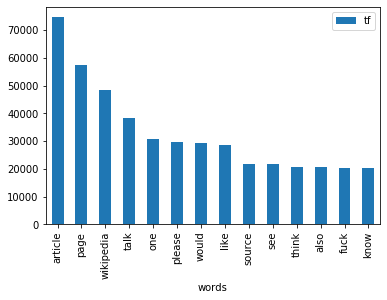

```python
a = tf1[tf1["tf"] > 20000]
a.plot.bar(x = "words", y = "tf");
```

## 1.4 Wordcloud

```python
import numpy as np
import pandas as pd
from os import path
from PIL import Image
from wordcloud import WordCloud, STOPWORDS, ImageColorGenerator
import matplotlib.pyplot as plt
from textblob import TextBlob
from sklearn import model_selection, preprocessing, linear_model, naive_bayes, metrics
from sklearn.feature_extraction.text import TfidfVectorizer, CountVectorizer
from sklearn import decomposition, ensemble

import pandas, xgboost, numpy, textblob, string
from keras.preprocessing import text, sequence
from keras import layers, models, optimizers


from warnings import filterwarnings
filterwarnings('ignore')
```

```python
data.head(3)
```

|  | comment_text | identity_hate | insult | obscene | severe_toxic | threat | toxic |
| --- | --- | --- | --- | --- | --- | --- | --- |
| 0 | explanation edits made username hardcore metal... | 0.0 | 0.0 | 0.0 | 0.0 | 0.0 | 0.0 |
| 1 | match background colour seemingly stuck thanks... | 0.0 | 0.0 | 0.0 | 0.0 | 0.0 | 0.0 |
| 2 | hey man really trying edit war guy constantly ... | 0.0 | 0.0 | 0.0 | 0.0 | 0.0 | 0.0 |

```python
x = data.iloc[:,1:].sum()
```

```python
rowsums=data.iloc[:,1:].sum(axis=1)

#marking comments without any tags as "clean"
data['clean'] = (rowsums==0)
#count number of clean entries
data['clean'].sum()
print("Total comments = ",len(data))
print("Total clean comments = ",data['clean'].sum())
```

```
Total comments =  159571
Total clean comments =  143346
```

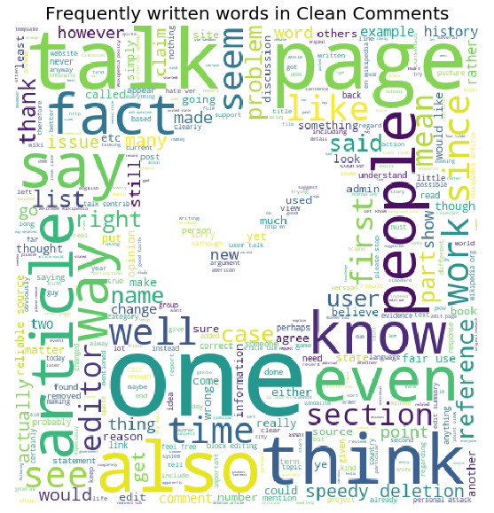

```python
#clean comments
clean_mask = np.array(Image.open("safe.png"))
clean_mask = clean_mask[:,:,1]
#wordcloud for clean comments
subset = data[data.clean==True]
text = subset.comment_text.values
wc = WordCloud(background_color="white",max_words=500,mask=clean_mask,stopwords = sw)
wc.generate(" ".join(text))
plt.figure(figsize=(20,10))
plt.axis("off")
plt.title("Frequently written words in Clean Comments", fontsize=20)
plt.imshow(wc.recolor(colormap= 'viridis' , random_state=17), alpha=0.98)
plt.show()
```

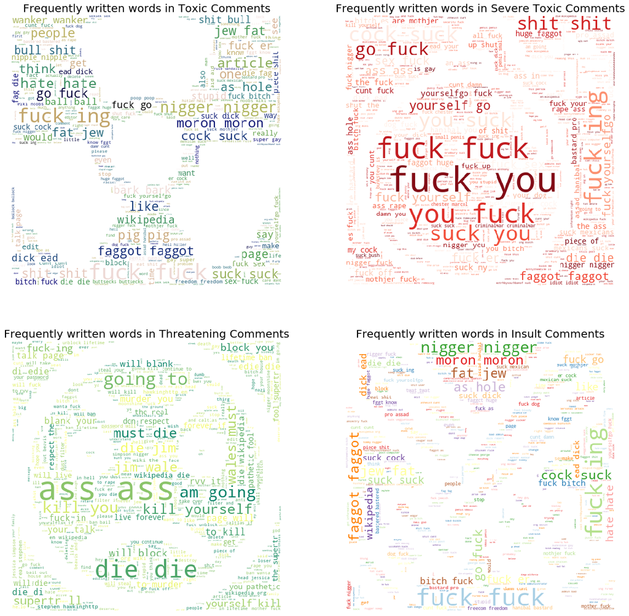

```python
toxic_mask = np.array(Image.open("toxic.png"))
toxic_mask = toxic_mask[:,:,1]
#wordcloud for toxic comments
subset = data[data.toxic==1]
text = subset.comment_text.values
wc = WordCloud(background_color = "white", max_words = 750, mask = toxic_mask,stopwords = sw)
wc.generate(" ".join(text))
plt.figure(figsize=(20,20))
plt.subplot(221)
plt.axis("off")
plt.title("Frequently written words in Toxic Comments", fontsize=20)
plt.imshow(wc.recolor(colormap= 'gist_earth' , random_state=244), alpha=0.98)

#Severely toxic comments
plt.subplot(222)
severe_toxic_mask=np.array(Image.open("bomb.png"))
severe_toxic_mask=severe_toxic_mask[:,:,1]
subset=train[train.severe_toxic == 1]
text=subset.comment_text.values
wc= WordCloud(background_color = "white", max_words = 750, mask = severe_toxic_mask,stopwords = sw)
wc.generate(" ".join(text))
plt.axis("off")
plt.title("Frequently written words in Severe Toxic Comments", fontsize=20)
plt.imshow(wc.recolor(colormap= 'Reds' , random_state=244), alpha=0.98)

#Threat comments
plt.subplot(223)
threat_mask=np.array(Image.open("anger.png"))
threat_mask=threat_mask[:,:,1]
subset=train[train.threat == 1]
text=subset.comment_text.values
wc= WordCloud(background_color = "white",max_words = 750, mask = threat_mask, stopwords = sw)
wc.generate(" ".join(text))
plt.axis("off")
plt.title("Frequently written words in Threatening Comments", fontsize=20)
plt.imshow(wc.recolor(colormap= 'summer' , random_state=2534), alpha=0.98)


#insult
plt.subplot(224)
insult_mask = np.array(Image.open("sword.png"))
insult_mask = insult_mask[:,:,1]
subset = data[data.insult == 1]
text = subset.comment_text.values
wc = WordCloud(background_color="white", max_words = 750, mask=insult_mask, stopwords = sw)
wc.generate(" ".join(text))
plt.axis("off")
plt.title("Frequently written words in Insult Comments", fontsize=20)
plt.imshow(wc.recolor(colormap= 'Paired_r' , random_state=244), alpha=0.98)

plt.show()
```

## 1.5 Classification Text

```python
from sklearn.feature_extraction.text import TfidfVectorizer
from sklearn.model_selection import train_test_split
```

```python
train_df = train.copy()
test_df = test.copy()
```

```python
test_df = test_df[["comment_text","id"]]
```

```python
test_df["comment_text"].fillna("unknown", inplace=True)
```

```python
classes = ['identity_hate', 'insult', 'obscene', 'severe_toxic', 'threat', 'toxic']
```

```python
text = pd.concat([train_df['comment_text'],test_df['comment_text']]).reset_index(drop=True)
```

```python
tfidf = TfidfVectorizer(
    sublinear_tf = True,
    strip_accents = 'unicode',
    analyzer = 'word',
    token_pattern = r'[a-z]{3,}',
    stop_words = sw ,
    ngram_range = (1, 2),
    max_df = 50000,
    max_features = 5000)

tfidf.fit(text)
train_features = tfidf.transform(train_df['comment_text'])

X_train, X_test, y_train, y_test = train_test_split(train_features.toarray(),
                                                    train_df[classes], test_size=0.3,
                                                    random_state=0)
```

```python
"Get the top n values tfidf overlap and rotate with the corresponding attribute name.."

def top_tfidf_feats(row, features, top_n=30):
    topn_ids = np.argsort(row)[::-1][:top_n]
    top_feats = [(features[i], row[i]) for i in topn_ids]
    df = pd.DataFrame(top_feats)
    df.columns = ['feature', 'tfidf']
    return df

"On average, return the most important of the properties among documents in rows specified in Grp_ids directories."

def top_mean_feats(Xtr, features, grp_ids, min_tfidf=0.1, top_n=30):
    D = Xtr[grp_ids].toarray()
    D[D < min_tfidf] = 0
    tfidf_means = np.mean(D, axis=0)
    return top_tfidf_feats(tfidf_means, features, top_n)


# modified for multilabel milticlass
"Returns a list of dfs where each df contains the properties of top_n and the average tfidf value calculated between documents with the same class tag."
def top_feats_by_class(Xtr, features, min_tfidf=0.1, top_n=30):
    dfs = []
    columns_ = train_tags.columns
    for col in columns_:
        ids = train_tags.index[train_tags[col] == 1]
        feats_df = top_mean_feats(Xtr, features, ids, min_tfidf=min_tfidf, top_n=top_n)
        feats_df.label = classes
        dfs.append(feats_df)
    return dfs
```

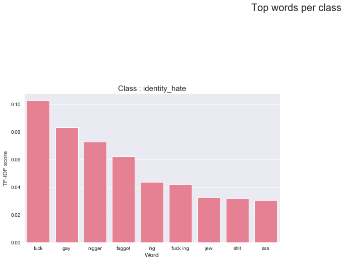

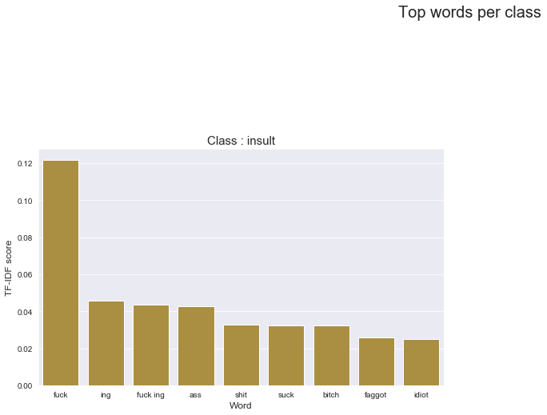

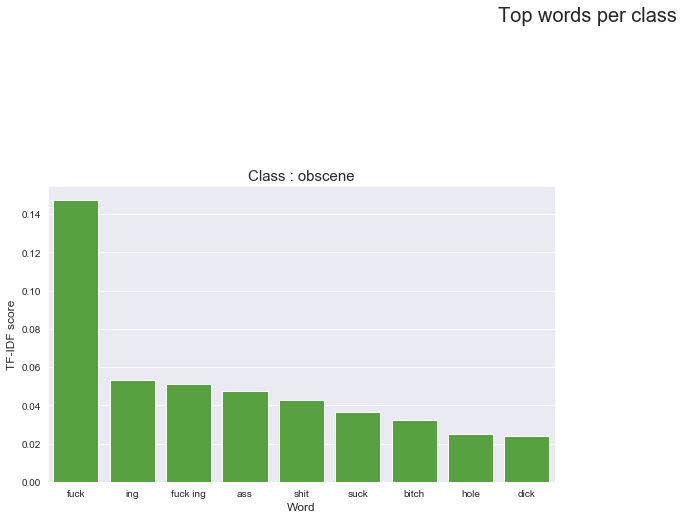

[figure not shown]

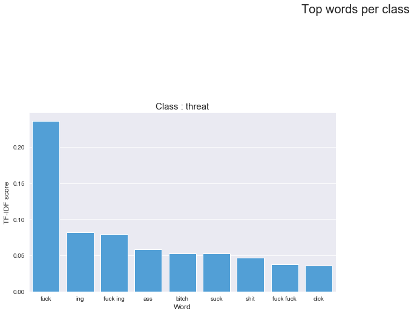

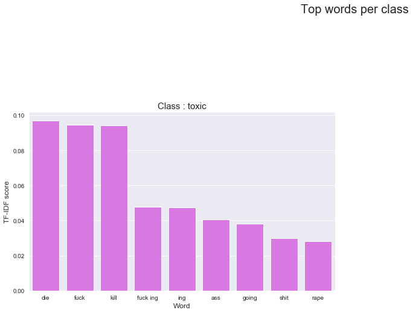

```python
import matplotlib.pyplot as plt
import matplotlib.gridspec as gridspec
import seaborn as sns
from PIL import Image

train_tags = train_df.iloc[:,2:]
features = np.array(tfidf.get_feature_names())
train_unigram =  tfidf.transform(text.iloc[:train_df.shape[0]])
tfidf_top_n_class = top_feats_by_class(train_unigram,features)


tfidf.fit(text)
train_features = tfidf.transform(train_df['comment_text'])

color = sns.color_palette("husl")
sns.set_style("darkgrid")
i = 0

for class_ in classes:
    plt.figure(figsize=(20,25))
    plt.suptitle("Top words per class",fontsize=20)
    gridspec.GridSpec(4,2)
    plt.subplot2grid((4,2),(0,0))
    sns.barplot(tfidf_top_n_class[i].feature.iloc[0:9], tfidf_top_n_class[i].tfidf.iloc[0:9], color = color[i])
    plt.title("Class : {}".format(class_),fontsize = 15)
    plt.xlabel('Word', fontsize = 12)
    plt.ylabel('TF-IDF score', fontsize = 12)
    i= i+1
```

# 2. Comparing Algorithms

```python
from textblob import TextBlob
from sklearn import model_selection, preprocessing, linear_model, naive_bayes, metrics
from sklearn.feature_extraction.text import TfidfVectorizer, CountVectorizer
from sklearn import decomposition, ensemble
from sklearn.model_selection import train_test_split
import pandas, xgboost, numpy, textblob, string
from keras.preprocessing import text, sequence
from keras import layers, models, optimizers


from warnings import filterwarnings
filterwarnings('ignore')
```

```python
train_df_1 = train.copy()
test_df_1  = test.copy()
test_df_1 = test_df.fillna(' ')
```

```python
#uppercase / lowercase transformation
train_df_1["comment_text"] = train_df["comment_text"].apply(lambda x: " ".join(x.lower() for x in x.split()))
#removing punctuation marks
train_df_1["comment_text"] = train_df["comment_text"].str.replace('[^\w\s]','')
#removal of numbers
train_df_1["comment_text"] = train_df["comment_text"].str.replace('\d','')
#stopwords
train_df_1["comment_text"] = train_df["comment_text"].apply(lambda x: " ".join(x for x in x.split() if x not in sw))
#deleting rare words
train_df_1["comment_text"] = train_df["comment_text"].apply(lambda x: " ".join(x for x in x.split() if x not in del_))
#lemmi
train_df_1["comment_text"] = train_df["comment_text"].apply(lambda x: " ".join([Word(word).lemmatize() for word in x.split()]))
```

```python
labels = ['toxic', 'severe_toxic', 'obscene', 'threat', 'insult', 'identity_hate']
train, test = train_test_split(train_df_1, test_size=0.33, random_state=42, shuffle=True)
```

```python
train.shape, test.shape
```

```
((106912, 10), (52659, 10))
```

```python
X_train = train['comment_text']
X_test = test['comment_text']
```

## 2.1.1 Count Vectors

```python
vectorizer = CountVectorizer()
start = time.time()
vectorizer.fit(X_train)
duration_ = time.time() - start
toaster.show_toast("Count Vectors training completed.",
                   f"Duration : {duration_}", duration = 5)
```

[output not shown]

```python
X_train_count = vectorizer.transform(X_train)
X_test_count = vectorizer.transform(X_test)
```

### 2.1.2 TF-IDF

```python
#wordlevel
tf_idf_word_vectorizer = TfidfVectorizer()
start = time.time()
tf_idf_word_vectorizer.fit(X_train)
duration_ = time.time() - start
toaster.show_toast("TF-IDF training completed.",
                   f"Duration : {duration_}", duration = 5)
```

[output not shown]

```python
X_train_tf_idf_word = tf_idf_word_vectorizer.transform(X_train)
X_test_tf_idf_word = tf_idf_word_vectorizer.transform(X_test)
```

### 2.1.3 NGram Level TF-IDF

```python
tf_idf_ngram_vectorizer = TfidfVectorizer(ngram_range = (2,3)) # actually ngram_range(1,2) gives better results but it takes too long
start = time.time()
tf_idf_ngram_vectorizer.fit(X_train)
duration_ = time.time() - start
toaster.show_toast("NGram TF-IDF training completed.",
                   f"Duration : {duration_}", duration = 5)
```

[output not shown]

```python
X_train_tf_idf_ngram = tf_idf_ngram_vectorizer.transform(X_train)
X_test_tf_idf_ngram = tf_idf_ngram_vectorizer.transform(X_test)
```

### 2.1.4 Character Level TF-IDF

```python
tf_idf_chars_vectorizer = TfidfVectorizer(analyzer = "char", ngram_range = (2,3))
start = time.time()
tf_idf_chars_vectorizer.fit(X_train)
duration_ = time.time() - start
toaster.show_toast("Character based TF-IDF training completed.",
                   f"Duration : {duration_}", duration = 5)
```

[output not shown]

```python
X_train_tf_idf_chars = tf_idf_chars_vectorizer.transform(X_train)
X_test_tf_idf_chars = tf_idf_chars_vectorizer.transform(X_test)
```

```python
accuracies = [[],[],[],[],[],[]]
```

# 2.2 ML Algorithms

## 2.2.1 Multinomial Naive Bayes

```python
accuracies_nb = [[],[],[],[]]
```

```python
from sklearn.naive_bayes import MultinomialNB
```

```python
start = time.time()

for category in labels:
    model1_cnt = MultinomialNB()
    model1_cnt.fit(X_train_count, train[category])
    accuracy =  model_selection.cross_val_score(model1_cnt,
                                           X_test_count,
                                           test[category],
                                           cv = 10).mean()
    accuracies_nb[0].append(accuracy)
    print("Accuracy For {0} Class Is {1}%".format(category,round(accuracy*100,2)))

duration_ = time.time() - start
toaster.show_toast("Count vector based Naive Bayes training and testing completed.",
                   f"Duration : {duration_}", duration = 5)
```

```
Accuracy For toxic Class Is 94.4%
Accuracy For severe_toxic Class Is 98.97%
Accuracy For obscene Class Is 96.68%
Accuracy For threat Class Is 99.66%
Accuracy For insult Class Is 96.27%
Accuracy For identity_hate Class Is 98.98%
```

```python
start = time.time()

for category in labels:
    model1_tf = MultinomialNB()
    model1_tf.fit(X_train_tf_idf_word, train[category])
    accuracy = model_selection.cross_val_score(model1_tf,
                                           X_test_tf_idf_word,
                                           test[category],
                                           cv = 10).mean()
    accuracies_nb[1].append(accuracy)
    print("Accuracy For {0} Class Is {1}%".format(category,round(accuracy*100,2)))
duration_ = time.time() - start
toaster.show_toast("Word based TF-IDF - Naive Bayes training and testing completed.",
                   f"Duration : {duration_}", duration = 5)
```

```
Accuracy For toxic Class Is 91.16%
Accuracy For severe_toxic Class Is 99.0%
Accuracy For obscene Class Is 94.82%
Accuracy For threat Class Is 99.71%
Accuracy For insult Class Is 95.02%
Accuracy For identity_hate Class Is 99.11%
```

```python
start = time.time()

for category in labels:
    model1_ngr = MultinomialNB()
    model1_ngr.fit(X_train_tf_idf_ngram, train[category])
    accuracy = model_selection.cross_val_score(model1_ngr,
                                           X_test_tf_idf_ngram,
                                           test[category],
                                           cv = 10).mean()
    accuracies_nb[2].append(accuracy)
    print("Accuracy For {0} Class Is {1}%".format(category,round(accuracy*100,2)))
duration_ = time.time() - start
toaster.show_toast("NGram based TF-IDF - Naive Bayes training and testing completed.",
                   f"Duration : {duration_}", duration = 5)
```

```
Accuracy For toxic Class Is 90.78%
Accuracy For severe_toxic Class Is 99.0%
Accuracy For obscene Class Is 94.79%
Accuracy For threat Class Is 99.71%
Accuracy For insult Class Is 95.03%
Accuracy For identity_hate Class Is 99.11%
```

```python
start = time.time()

for category in labels:
    model1_tf_c = MultinomialNB()
    model1_tf_c.fit(X_train_tf_idf_chars, train[category])
    accuracy = model_selection.cross_val_score(model1_tf_c,
                                           X_test_tf_idf_chars,
                                           test[category],
                                           cv = 10).mean()
    accuracies_nb[3].append(accuracy)
    print("Accuracy For {0} Class Is {1}%".format(category,round(accuracy*100,2)))
duration_ = time.time() - start
toaster.show_toast("Character based TF-IDF - Naive Bayes training and testing completed.",
                   f"Duration : {duration_}", duration = 5)
```

```
Accuracy For toxic Class Is 92.23%
Accuracy For severe_toxic Class Is 98.99%
Accuracy For obscene Class Is 95.62%
Accuracy For threat Class Is 99.7%
Accuracy For insult Class Is 95.56%
Accuracy For identity_hate Class Is 99.08%
```

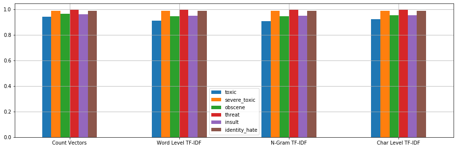

```python
accuracies_nb = pd.DataFrame(accuracies_nb)
fig = accuracies_nb.plot.bar(figsize=(16, 5), grid=True)
plt.xticks(np.arange(4),('Count Vectors','Word Level TF-IDF','N-Gram TF-IDF', 'Char Level TF-IDF'),rotation=0)
plt.legend(labels)
plt.show()
```

```python
for i in range(4):
    print("Model -",i+1,"... Aggregate Accuracy -",np.mean(accuracies_nb.iloc[i,:]))
```

```
Model - 1 ... Aggregate Accuracy - 0.9749425324253362
Model - 2 ... Aggregate Accuracy - 0.9646784006342178
Model - 3 ... Aggregate Accuracy - 0.964032737263315
Model - 4 ... Aggregate Accuracy - 0.9686410014755374
```

```python
# in our Multinomial Naive Bayes model, count vectors gave better result

accuracies[0].append(np.mean(accuracies_nb.iloc[0,:]))
```

## 2.2.2 Logistic Regression Classifier

```python
accuracies_lr = [[],[],[],[]]
```

```python
from sklearn.linear_model import LogisticRegression
model2_cnt = LogisticRegression(n_jobs=-1, solver='liblinear')
start = time.time()

for category in labels:
    model2_cnt.fit(X_train_count, train[category])
    accuracy = model_selection.cross_val_score(model2_cnt,
                                           X_test_count,
                                           test[category],
                                           cv = 10).mean()
    accuracies_lr[0].append(accuracy)
    print("Accuracy For {0} Class Is {1}%".format(category,round(accuracy*100,2)))
duration_ = time.time() - start
toaster.show_toast("Count Vector based Logit training and testing completed.",
                   f"Duration : {duration_}", duration = 5)
```

```
Accuracy For toxic Class Is 95.37%
Accuracy For severe_toxic Class Is 99.02%
Accuracy For obscene Class Is 97.16%
Accuracy For threat Class Is 99.66%
Accuracy For insult Class Is 95.81%
Accuracy For identity_hate Class Is 99.05%
```

```python
model2_tf = LogisticRegression(n_jobs=-1, solver='liblinear')
start = time.time()

for category in labels:
    model2_tf.fit(X_train_tf_idf_word, train[category])
    accuracy = model_selection.cross_val_score(model2_tf,
                                           X_test_tf_idf_word,
                                           test[category],
                                           cv = 10).mean()
    accuracies_lr[1].append(accuracy)
    print("Accuracy For {0} Class Is {1}%".format(category,round(accuracy*100,2)))

duration_ = time.time() - start
toaster.show_toast("TF-IDF based Logit training and testing completed.",
                   f"Duration : {duration_}", duration = 5)
```

```
Accuracy For toxic Class Is 95.39%
Accuracy For severe_toxic Class Is 99.06%
Accuracy For obscene Class Is 97.67%
Accuracy For threat Class Is 99.72%
Accuracy For insult Class Is 96.92%
Accuracy For identity_hate Class Is 99.18%
```

```python
model2_ngr = LogisticRegression(n_jobs=-1, solver='liblinear')

start = time.time()

for category in labels:
    model2_ngr.fit(X_train_tf_idf_ngram, train[category])
    accuracy = model_selection.cross_val_score(model2_ngr,
                                           X_test_tf_idf_ngram,
                                           test[category],
                                           cv = 10).mean()
    accuracies_lr[2].append(accuracy)
    print("Accuracy For {0} Class Is {1}%".format(category,round(accuracy*100,2)))

duration_ = time.time() - start
toaster.show_toast("NGram based TFIDF - Logit training and testing completed.",
                   f"Duration : {duration_}", duration = 5)
```

```
Accuracy For toxic Class Is 92.21%
Accuracy For severe_toxic Class Is 99.0%
Accuracy For obscene Class Is 95.87%
Accuracy For threat Class Is 99.71%
Accuracy For insult Class Is 95.71%
Accuracy For identity_hate Class Is 99.11%
```

```python
model2_tf_c = LogisticRegression(n_jobs=-1, solver='liblinear')
start = time.time()

for category in labels:
    model2_tf_c.fit(X_train_tf_idf_chars, train[category])
    accuracy = model_selection.cross_val_score(model2_tf_c,
                                           X_test_tf_idf_chars,
                                           test[category],
                                           cv = 10).mean()
    accuracies_lr[3].append(accuracy)
    print("Accuracy For {0} Class Is {1}%".format(category,round(accuracy*100,2)))

duration_ = time.time() - start
toaster.show_toast("Character based TF-IDF - Logit training and testing completed.",
                   f"Duration : {duration_}", duration = 5)
```

```
Accuracy For toxic Class Is 95.02%
Accuracy For severe_toxic Class Is 99.08%
Accuracy For obscene Class Is 97.49%
Accuracy For threat Class Is 99.72%
Accuracy For insult Class Is 96.87%
Accuracy For identity_hate Class Is 99.19%
```

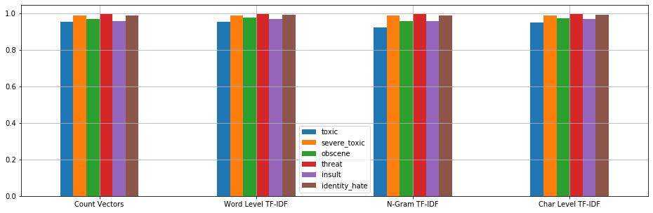

```python
accuracies_lr = pd.DataFrame(accuracies_lr)
fig = accuracies_lr.plot.bar(figsize=(16, 5), grid=True)
plt.xticks(np.arange(4),('Count Vectors','Word Level TF-IDF','N-Gram TF-IDF', 'Char Level TF-IDF'),rotation=0)
plt.legend(labels)
plt.show()
```

```python
for i in range(4):
    print("Model -",i+1," Accuracy -",np.mean(accuracies_lr.iloc[i,:]))
```

[output not shown]

```python
# in our Logistic Regression model, Word Level TF-IDF gave better result

accuracies[1].append(np.mean(accuracies_lr.iloc[1,:]))
```

## 2.2.3 Linear Support Vector Classifier

```python
accuracies_svc = [[],[],[],[]]
```

```python
from sklearn.svm import LinearSVC
model3_cnt = LinearSVC()
start = time.time()

for category in labels:
    model3_cnt.fit(X_train_count, train[category])
    accuracy = model_selection.cross_val_score(model3_cnt,
                                           X_test_count,
                                           test[category],
                                           cv = 10).mean()
    accuracies_svc[0].append(accuracy)
    print("Accuracy For {0} Class Is {1}%".format(category,round(accuracy*100,2)))

duration_ = time.time() - start
toaster.show_toast("Count Vector based SVC training and testing completed.",
                   f"Duration : {duration_}", duration = 5)
```

```
Accuracy For toxic Class Is 95.15%
Accuracy For severe_toxic Class Is 98.73%
Accuracy For obscene Class Is 97.52%
Accuracy For threat Class Is 99.61%
Accuracy For insult Class Is 96.2%
Accuracy For identity_hate Class Is 98.87%
```

```python
model3_tf = LinearSVC()
start = time.time()

for category in labels:
    model3_tf.fit(X_train_tf_idf_word, train[category])
    accuracy = model_selection.cross_val_score(model3_tf,
                                           X_test_tf_idf_word,
                                           test[category],
                                           cv = 10).mean()
    accuracies_svc[1].append(accuracy)
    print("Accuracy For {0} Class Is {1}%".format(category,round(accuracy*100,2)))

duration_ = time.time() - start
toaster.show_toast("TF-IDF based SVC training and testing completed.",
                   f"Duration : {duration_}", duration = 5)
```

```
Accuracy For toxic Class Is 95.96%
Accuracy For severe_toxic Class Is 99.05%
Accuracy For obscene Class Is 97.92%
Accuracy For threat Class Is 99.73%
Accuracy For insult Class Is 97.08%
Accuracy For identity_hate Class Is 99.21%
```

```python
model3_ngr = LinearSVC()
start = time.time()

for category in labels:
    model3_ngr.fit(X_train_tf_idf_ngram, train[category])
    accuracy = model_selection.cross_val_score(model3_ngr,
                                           X_test_tf_idf_ngram,
                                           test[category],
                                           cv = 10).mean()
    accuracies_svc[2].append(accuracy)
    print("Accuracy For {0} Class Is {1}%".format(category,round(accuracy*100,2)))

duration_ = time.time() - start
toaster.show_toast("NGram based TF-IDF - SVC training and testing completed.",
                   f"Duration : {duration_}", duration = 5)
```

```
Accuracy For toxic Class Is 93.92%
Accuracy For severe_toxic Class Is 99.03%
Accuracy For obscene Class Is 96.96%
Accuracy For threat Class Is 99.75%
Accuracy For insult Class Is 96.35%
Accuracy For identity_hate Class Is 99.12%
```

```python
model3_tf_c = LinearSVC()
start = time.time()

for category in labels:
    model3_tf_c.fit(X_train_tf_idf_chars, train[category])
    accuracy = model_selection.cross_val_score(model3_tf_c,
                                           X_test_tf_idf_chars,
                                           test[category],
                                           cv = 10).mean()
    accuracies_svc[3].append(accuracy)
    print("Accuracy For {0} Class Is {1}%".format(category,round(accuracy*100,2)))

duration_ = time.time() - start
toaster.show_toast("Char based TF-IDF - SVC training and testing completed.",
                   f"Duration : {duration_}", duration = 5)
```

```
Accuracy For toxic Class Is 95.62%
Accuracy For severe_toxic Class Is 99.08%
Accuracy For obscene Class Is 97.82%
Accuracy For threat Class Is 99.75%
Accuracy For insult Class Is 97.13%
Accuracy For identity_hate Class Is 99.22%
```

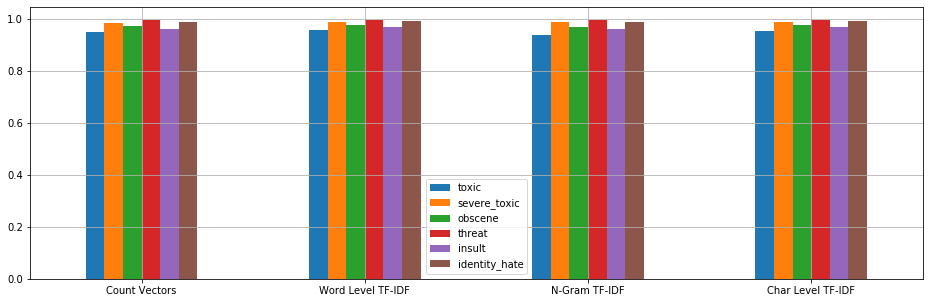

```python
accuracies_svc = pd.DataFrame(accuracies_svc)
fig = accuracies_svc.plot.bar(figsize=(16, 5), grid=True)
plt.xticks(np.arange(4),('Count Vectors','Word Level TF-IDF','N-Gram TF-IDF', 'Char Level TF-IDF'),rotation=0)
plt.legend(labels)
plt.show()
```

```python
for i in range(4):
    print("Model -",i+1,"... Aggregate Accuracy -",np.mean(accuracies_svc.iloc[i,:]))
```

```
Model - 1 ... Aggregate Accuracy - 0.9768067279123532
Model - 2 ... Aggregate Accuracy - 0.9815637763901256
Model - 3 ... Aggregate Accuracy - 0.9752084147115164
Model - 4 ... Aggregate Accuracy - 0.9810288781190161
```

```python
# in our Support Vector Classifier model, Word Level TF-IDF gave better result

accuracies[2].append(np.mean(accuracies_svc.iloc[1,:]))
```

## 2.2.4 Random Forests

```python
accuracies_rf = [[],[],[],[]]
```

```python
from sklearn.ensemble import RandomForestClassifier
model4_cnt = RandomForestClassifier(n_jobs=-1)
start = time.time()

for category in labels:
    model4_cnt.fit(X_train_count, train[category])
    accuracy = model_selection.cross_val_score(model4_cnt,
                                           X_test_count,
                                           test[category],
                                           cv = 10).mean()
    accuracies_rf[0].append(accuracy)
    print("Accuracy For {0} Class Is {1}%".format(category,round(accuracy*100,2)))

duration_ = time.time() - start
toaster.show_toast("Count Vector based Random Forest training and testing completed.",
                   f"Duration : {duration_}", duration = 5)
```

```
Accuracy For toxic Class Is 94.08%
Accuracy For severe_toxic Class Is 99.01%
Accuracy For obscene Class Is 96.87%
Accuracy For threat Class Is 99.71%
Accuracy For insult Class Is 96.29%
Accuracy For identity_hate Class Is 99.12%
```

```python
model4_tf = RandomForestClassifier(n_jobs=-1)
start = time.time()

for category in labels:
    model4_tf.fit(X_train_tf_idf_word, train[category])
    accuracy = model_selection.cross_val_score(model4_tf,
                                           X_test_tf_idf_word,
                                           test[category],
                                           cv = 10).mean()
    accuracies_rf[1].append(accuracy)
    print("Accuracy For {0} Class Is {1}%".format(category,round(accuracy*100,2)))

duration_ = time.time() - start
toaster.show_toast("TF-IDF based - Random Forest training and testing completed.",
                   f"Duration : {duration_}", duration = 5)
```

```
Accuracy For toxic Class Is 93.99%
Accuracy For severe_toxic Class Is 99.01%
Accuracy For obscene Class Is 96.86%
Accuracy For threat Class Is 99.71%
Accuracy For insult Class Is 96.23%
Accuracy For identity_hate Class Is 99.12%
```

```python
model4_ngr = RandomForestClassifier(n_jobs=-1)
start = time.time()

for category in labels:
    model4_ngr.fit(X_train_tf_idf_ngram, train[category])
    # accuracy = model_selection.cross_val_score(model4_ngr,   X_test_tf_idf_ngram, test[category], cv = 10).mean()
    accuracy = model4_ngr.score(X_test_tf_idf_ngram, test[category])
    accuracies_rf[2].append(accuracy)
    print("Accuracy For {0} Class Is {1}%".format(category,round(accuracy*100,2)))

duration_ = time.time() - start
toaster.show_toast("NGram based TF-IDF - Random Forest training and testing completed.",
                   f"Duration : {duration_}", duration = 5)
```

```
Accuracy For toxic Class Is 94.28%
Accuracy For severe_toxic Class Is 99.01%
Accuracy For obscene Class Is 97.26%
Accuracy For threat Class Is 99.72%
Accuracy For insult Class Is 96.42%
Accuracy For identity_hate Class Is 99.11%
```

```python
model4_tf_c = RandomForestClassifier(n_jobs=-1)
start = time.time()

for category in labels:
    model4_tf_c.fit(X_train_tf_idf_chars, train[category])
    # accuracy = model_selection.cross_val_score(model4_tf_c, X_test_tf_idf_chars, test[category], cv = 10).mean()
    accuracy = model4_tf_c.score(X_test_tf_idf_chars, test[category])
    accuracies_rf[3].append(accuracy)
    print("Accuracy For {0} Class Is {1}%".format(category,round(accuracy*100,2)))

duration_ = time.time() - start
toaster.show_toast("Char based TF-IDF - Random Forest training and testing completed.",
                   f"Duration : {duration_}", duration = 5)
```

```
Accuracy For toxic Class Is 93.68%
Accuracy For severe_toxic Class Is 99.01%
Accuracy For obscene Class Is 97.0%
Accuracy For threat Class Is 99.72%
Accuracy For insult Class Is 96.29%
Accuracy For identity_hate Class Is 99.16%
```

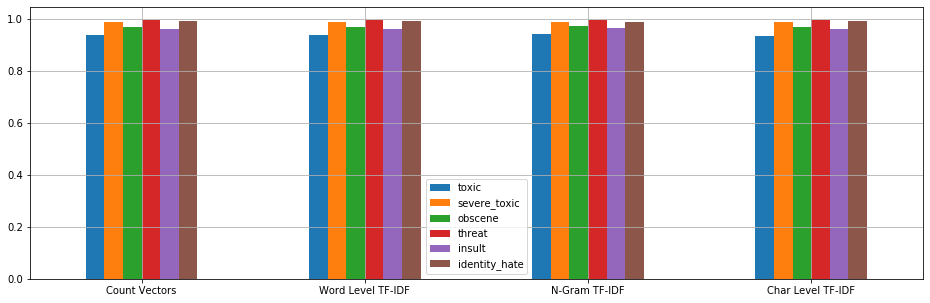

```python
accuracies_rf = pd.DataFrame(accuracies_rf)
fig = accuracies_rf.plot.bar(figsize=(16, 5), grid=True)
plt.xticks(np.arange(4),('Count Vectors','Word Level TF-IDF','N-Gram TF-IDF', 'Char Level TF-IDF'),rotation=0)
plt.legend(labels)
plt.show()
```

```python
for i in range(4):
    print("Model -",i+1,"... Aggregate Accuracy -",np.mean(accuracies_rf.iloc[i,:]))
```

```
Model - 1 ... Aggregate Accuracy - 0.975126110785899
Model - 2 ... Aggregate Accuracy - 0.9748697558335909
Model - 3 ... Aggregate Accuracy - 0.9763256676604822
Model - 4 ... Aggregate Accuracy - 0.9747368287788728
```

```python
# in our Random Forests model, N-Gram gave better result

accuracies[3].append(np.mean(accuracies_rf.iloc[2,:]))
```

## 2.2.5 Gradient Boosting Classifier

```python
accuracies_gb = [[],[],[],[]]
```

```python
from sklearn.ensemble import GradientBoostingClassifier
```

```python
model5_cnt = GradientBoostingClassifier()
start = time.time()

for category in labels:
    model5_cnt.fit(X_train_count, train[category])
    accuracy = model5_cnt.score(X_test_count, test[category])
    # It takes too long
    #(accuracy = model_selection.cross_val_score(model5_cnt, X_test_count, test[category],cv = 10).mean())
    accuracies_gb[0].append(accuracy)
    print("Accuracy For {0} Class Is {1}%".format(category,round(accuracy*100,2)))

duration_ = time.time() - start
toaster.show_toast("Count Vector based Gradient Boosting training and testing completed.",
                   f"Duration : {duration_}", duration = 5)
```

```
Accuracy For toxic Class Is 94.9%
Accuracy For severe_toxic Class Is 99.02%
Accuracy For obscene Class Is 97.78%
Accuracy For threat Class Is 99.66%
Accuracy For insult Class Is 96.83%
Accuracy For identity_hate Class Is 99.12%
```

```python
model5_tf = GradientBoostingClassifier()
start = time.time()

for category in labels:
    model5_tf.fit(X_train_tf_idf_word, train[category])
    #accuracy = model_selection.cross_val_score(model5_tf, X_test_tf_idf_word, test[category], cv = 10).mean()
    accuracy = model5_tf.score(X_test_count, test[category])
    accuracies_gb[1].append(accuracy)
    print("Accuracy For {0} Class Is {1}%".format(category,round(accuracy*100,2)))

duration_ = time.time() - start
toaster.show_toast("Word based TF-IDF - Gradient Boosting training and testing completed.",
                   f"Duration : {duration_}", duration = 5)
```

```
Accuracy For toxic Class Is 94.43%
Accuracy For severe_toxic Class Is 97.5%
Accuracy For obscene Class Is 96.85%
Accuracy For threat Class Is 99.26%
Accuracy For insult Class Is 96.74%
Accuracy For identity_hate Class Is 95.93%
```

```python
model5_ngr = GradientBoostingClassifier()
start = time.time()

for category in labels:
    model5_ngr.fit(X_train_tf_idf_ngram, train[category])
    #accuracy = model_selection.cross_val_score(model5_ngr,  X_test_tf_idf_ngram,  test[category],  cv = 10).mean()
    accuracy = model5_ngr.score(X_test_tf_idf_ngram, test[category])
    accuracies_gb[2].append(accuracy)
    print("Accuracy For {0} Class Is {1}%".format(category,round(accuracy*100,2)))

duration_ = time.time() - start
toaster.show_toast("NGram based TF-IDF - Gradient Boosting training and testing completed.",
                   f"Duration : {duration_}", duration = 5)
```

```
Accuracy For toxic Class Is 93.03%
Accuracy For severe_toxic Class Is 98.92%
Accuracy For obscene Class Is 97.03%
Accuracy For threat Class Is 99.75%
Accuracy For insult Class Is 96.33%
Accuracy For identity_hate Class Is 98.95%
```

```python
model5_tf_c = GradientBoostingClassifier()
start = time.time()

for category in labels:
    model5_tf_c.fit(X_train_tf_idf_chars, train[category])
    #accuracy = model_selection.cross_val_score(model5_tf_c,  X_test_tf_idf_chars,  test[category],  cv = 10).mean()
    accuracy = model5_tf_c.score(X_test_tf_idf_chars, test[category])
    accuracies_gb[3].append(accuracy)
    print("Accuracy For {0} Class Is {1}%".format(category,round(accuracy*100,2)))

duration_ = time.time() - start
toaster.show_toast("Char based TF-IDF - Gradient Boosting training and testing completed.",
                   f"Duration : {duration_}", duration = 5)
```

```
Accuracy For toxic Class Is 94.91%
Accuracy For severe_toxic Class Is 98.94%
Accuracy For obscene Class Is 97.82%
Accuracy For threat Class Is 99.66%
Accuracy For insult Class Is 96.98%
Accuracy For identity_hate Class Is 99.14%
```

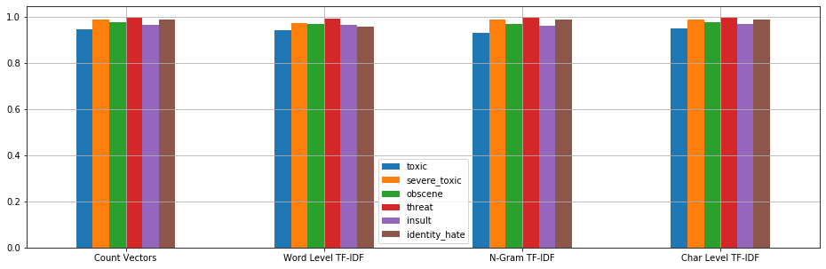

```python
accuracies_gb = pd.DataFrame(accuracies_gb)
fig = accuracies_gb.plot.bar(figsize=(16, 5), grid=True)
plt.xticks(np.arange(4),('Count Vectors','Word Level TF-IDF','N-Gram TF-IDF', 'Char Level TF-IDF'),rotation=0)
plt.legend(labels)
plt.show()
```

```python
for i in range(4):
    print("Model -",i+1,"... Aggregate Accuracy -",np.mean(accuracies_gb.iloc[i,:]))
```

```
Model - 1 ... Aggregate Accuracy - 0.9788481867613642
Model - 2 ... Aggregate Accuracy - 0.9678592453331815
Model - 3 ... Aggregate Accuracy - 0.9733347259411179
Model - 4 ... Aggregate Accuracy - 0.9791045531944523
```

```python
# in our Gradient Boosting model, Char Level TF-IDF gave better result

accuracies[4].append(np.mean(accuracies_gb.iloc[3,:]))
```

## 2.2.6 XGBoost Classifier

```python
accuracies_xgb = [[],[],[],[]]
```

```python
from xgboost import XGBClassifier
```

```python
model6_cnt = XGBClassifier()
start = time.time()

for category in labels:
    model6_cnt.fit(X_train_count, train[category])
    accuracy = model_selection.cross_val_score(model6_cnt,
                                           X_test_count,
                                           test[category],
                                           cv = 10).mean()
    accuracies_xgb[0].append(accuracy)
    print("Accuracy For {0} Class Is {1}%".format(category,round(accuracy*100,2)))

duration_ = time.time() - start
toaster.show_toast("Count Vector based  XGB training and testing completed.",
                   f"Duration : {duration_}", duration = 5)
```

```
Accuracy For toxic Class Is 95.69%
Accuracy For severe_toxic Class Is 99.04%
Accuracy For obscene Class Is 97.97%
Accuracy For threat Class Is 99.73%
Accuracy For insult Class Is 97.11%
Accuracy For identity_hate Class Is 99.22%
```

```python
model6_tf = XGBClassifier()
start = time.time()

for category in labels:
    model6_tf.fit(X_train_tf_idf_word, train[category])
    accuracy = model_selection.cross_val_score(model6_tf,
                                           X_test_tf_idf_word,
                                           test[category],
                                           cv = 10).mean()
    accuracies_xgb[1].append(accuracy)
    print("Accuracy For {0} Class Is {1}%".format(category,round(accuracy*100,2)))

duration_ = time.time() - start
toaster.show_toast("Word based TF-IDF - XGB training and testing completed.",
                   f"Duration : {duration_}", duration = 5)
```

```
Accuracy For toxic Class Is 95.61%
Accuracy For severe_toxic Class Is 98.99%
Accuracy For obscene Class Is 97.9%
Accuracy For threat Class Is 99.73%
Accuracy For insult Class Is 97.16%
Accuracy For identity_hate Class Is 99.25%
```

```python
model6_ngr = XGBClassifier()
start = time.time()

for category in labels:
    model6_ngr.fit(X_train_tf_idf_ngram, train[category])
    # accuracy = model_selection.cross_val_score(model6_ngr, X_test_tf_idf_ngram, test[category], cv = 10).mean()
    accuracy = model6_ngr.score(X_test_tf_idf_ngram, test[category])
    accuracies_xgb[2].append(accuracy)
    print("Accuracy For {0} Class Is {1}%".format(category,round(accuracy*100,2)))

duration_ = time.time() - start
toaster.show_toast("NGram based TF-IDF - XGB training and testing completed.",
                   f"Duration : {duration_}", duration = 5)
```

```
Accuracy For toxic Class Is 93.89%
Accuracy For severe_toxic Class Is 98.94%
Accuracy For obscene Class Is 97.31%
Accuracy For threat Class Is 99.74%
Accuracy For insult Class Is 96.59%
Accuracy For identity_hate Class Is 99.1%
```

```python
model6_tf_c = XGBClassifier()
start = time.time()

for category in labels:
    model6_tf_c.fit(X_train_tf_idf_chars, train[category])
    #accuracy = model_selection.cross_val_score(model6_tf_c, X_test_tf_idf_chars, test[category], cv = 10).mean()
    accuracy = model6_tf_c.score(X_test_tf_idf_chars, test[category])
    accuracies_xgb[3].append(accuracy)
    print("Accuracy For {0} Class Is {1}%".format(category,round(accuracy*100,2)))

duration_ = time.time() - start
toaster.show_toast("Char based TF-IDF - XGB training and testing completed.",
                   f"Duration : {duration_}", duration = 5)
```

```
Accuracy For toxic Class Is 95.66%
Accuracy For severe_toxic Class Is 99.03%
Accuracy For obscene Class Is 97.89%
Accuracy For threat Class Is 99.74%
Accuracy For insult Class Is 97.1%
Accuracy For identity_hate Class Is 99.24%
```

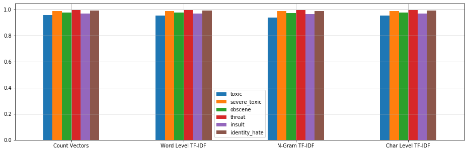

```python
accuracies_xgb = pd.DataFrame(accuracies_xgb)
fig = accuracies_xgb.plot.bar(figsize=(16, 5), grid=True)
plt.xticks(np.arange(4),('Count Vectors','Word Level TF-IDF','N-Gram TF-IDF', 'Char Level TF-IDF'),rotation=0)
plt.legend(labels)
plt.show()
```

```python
for i in range(4):
    print("Model -",i+1,"... Aggregate Accuracy -",np.mean(accuracies_xgb.iloc[i,:]))
```

```
Model - 1 ... Aggregate Accuracy - 0.9812757412042132
Model - 2 ... Aggregate Accuracy - 0.9810541743356024
Model - 3 ... Aggregate Accuracy - 0.9759268754312336
Model - 4 ... Aggregate Accuracy - 0.9810985143406952
```

```python
# in our xGBoost model, Count Vectors gave better result

accuracies[5].append(np.mean(accuracies_xgb.iloc[0,:]))
```

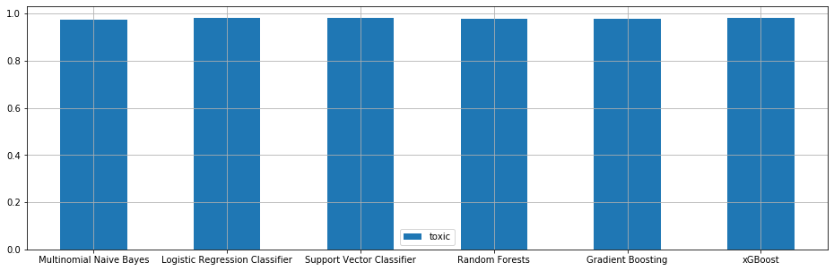

```python
accuracies = pd.DataFrame(accuracies)
fig = accuracies.plot.bar(figsize=(16, 5), grid=True)
plt.xticks(np.arange(6),('Multinomial Naive Bayes','Logistic Regression Classifier','Support Vector Classifier','Random Forests','Gradient Boosting', 'xGBoost'),rotation=0)
plt.legend(labels)
plt.show()
```

```python
for i in range(6):
    print("Model -",i+1,"Aggregate Accuracy -",np.mean(accuracies.iloc[i,:]))
```

```
Model - 1 Aggregate Accuracy - 0.9749425324253362
Model - 2 Aggregate Accuracy - 0.9799306143913057
Model - 3 Aggregate Accuracy - 0.9815637763901256
Model - 4 Aggregate Accuracy - 0.9763256676604822
Model - 5 Aggregate Accuracy - 0.9791045531944523
Model - 6 Aggregate Accuracy - 0.9812757412042132
```

```python
# According to the result of the average accuracy values,
# we got the best result in the support vector classifier/word level tf-idf.
```

# 3. Prediction

## 3.1 Preprocessing

```python
train = pd.read_csv('train_preprocessed.csv')
test = pd.read_csv('test_preprocessed.csv')
train_df = train.copy()
test_df = test.copy()
test_df = test_df.fillna(' ')
```

```python
#uppercase / lowercase transformation
train_df["comment_text"] = train_df["comment_text"].apply(lambda x: " ".join(x.lower() for x in x.split()))
test_df["comment_text"] = test_df["comment_text"].apply(lambda x: " ".join(x.lower() for x in x.split()))
#removing punctuation marks
train_df["comment_text"] = train_df["comment_text"].str.replace('[^\w\s]','')
test_df["comment_text"] = test_df["comment_text"].str.replace('[^\w\s]','')
#removal of numbers
train_df["comment_text"] = train_df["comment_text"].str.replace('\d','')
test_df["comment_text"] = test_df["comment_text"].str.replace('\d','')
#stopwords
train_df["comment_text"] = train_df["comment_text"].apply(lambda x: " ".join(x for x in x.split() if x not in sw))
test_df["comment_text"] = test_df["comment_text"].apply(lambda x: " ".join(x for x in x.split() if x not in sw))
#deleting rare words
train_df["comment_text"] = train_df["comment_text"].apply(lambda x: " ".join(x for x in x.split() if x not in del_))
test_df["comment_text"] = test_df["comment_text"].apply(lambda x: " ".join(x for x in x.split() if x not in del_))
#lemmin
train_df["comment_text"] = train_df["comment_text"].apply(lambda x: " ".join([Word(word).lemmatize() for word in x.split()]))
test_df["comment_text"] = test_df["comment_text"].apply(lambda x: " ".join([Word(word).lemmatize() for word in x.split()]))
```

```python
print("Total training data points:",len(train_df))
print("Total testing data points:",len(test_df))
```

```
Total training data points: 159571
Total testing data points: 153164
```

```python
# At this stage, we are still not concerned with toxicity.
labels = ['toxic', 'severe_toxic', 'obscene', 'threat', 'insult', 'identity_hate']
```

```python
#wordlevel
tf_idf_word_vectorizer = TfidfVectorizer()
tf_idf_word_vectorizer.fit(train_df['comment_text'])
```

```
TfidfVectorizer(analyzer='word', binary=False, decode_error='strict',
                dtype=<class 'numpy.float64'>, encoding='utf-8',
                input='content', lowercase=True, max_df=1.0, max_features=None,
                min_df=1, ngram_range=(1, 1), norm='l2', preprocessor=None,
                smooth_idf=True, stop_words=None, strip_accents=None,
                sublinear_tf=False, token_pattern='(?u)\\b\\w\\w+\\b',
                tokenizer=None, use_idf=True, vocabulary=None)
```

```python
X_train_tf_idf_word = tf_idf_word_vectorizer.transform(train_df['comment_text'])
X_test_tf_idf_word = tf_idf_word_vectorizer.transform(test_df['comment_text'])
```

```python
from sklearn.svm import LinearSVC
model = LinearSVC()
predictions = []
accuracy_list=[]
start = time.time()

for cat in labels:
    model.fit(X_train_tf_idf_word, train_df[cat]) #fitting the model
    y_pred = model.predict(X_test_tf_idf_word).tolist() #np array of predictions to list
    predictions.append(y_pred)

duration_ = time.time() - start
toaster.show_toast("Our prediction is over.",
                   f"Duration : {duration_}", duration = 5)
```

```python
test_result = pd.DataFrame({'comment': test_df['comment_text'],'id':test_df['id'],'toxic':predictions[0],'severe_toxic':predictions[1],'obscene':predictions[2],'threat':predictions[3],'insult':predictions[4],'identity_hate':predictions[5]})
```

```python
test_result
```

|  | comment | id | toxic | severe_toxic | obscene | threat | insult | identity_hate |
| --- | --- | --- | --- | --- | --- | --- | --- | --- |
| 0 | yo bitch ja rule succesful ever whats hating s... | 00001cee341fdb12 | 1.0 | 0.0 | 1.0 | 0.0 | 1.0 | 0.0 |
| 1 | rfc title fine imo | 0000247867823ef7 | 0.0 | 0.0 | 0.0 | 0.0 | 0.0 | 0.0 |
| 2 | source zawe ashton | 00013b17ad220c46 | 0.0 | 0.0 | 0.0 | 0.0 | 0.0 | 0.0 |
| 3 | look back source information updated correct f... | 00017563c3f7919a | 0.0 | 0.0 | 0.0 | 0.0 | 0.0 | 0.0 |
| 4 | anonymously edit article | 00017695ad8997eb | 0.0 | 0.0 | 0.0 | 0.0 | 0.0 | 0.0 |
| ... | ... | ... | ... | ... | ... | ... | ... | ... |
| 153159 | totally agree stuff nothing long crap | fffcd0960ee309b5 | 1.0 | 0.0 | 0.0 | 0.0 | 0.0 | 0.0 |
| 153160 | throw field home plate get faster throwing cut... | fffd7a9a6eb32c16 | 0.0 | 0.0 | 0.0 | 0.0 | 0.0 | 0.0 |
| 153161 | okinotorishima category see change agree corre... | fffda9e8d6fafa9e | 0.0 | 0.0 | 0.0 | 0.0 | 0.0 | 0.0 |
| 153162 | one founding nation eu germany law return quit... | fffe8f1340a79fc2 | 0.0 | 0.0 | 0.0 | 0.0 | 0.0 | 0.0 |
| 153163 | stop already bull shit welcome fool think kind... | ffffce3fb183ee80 | 1.0 | 0.0 | 1.0 | 0.0 | 0.0 | 0.0 |

153164 rows × 8 columns

```python
# Export to csv for prof
test_result.to_csv('our_output.csv')
```

## 3.2 Estimate the toxicity value as a result of our predictions.

In this step, we will use 2 different ML algorithms. These:

> 1-Decision Trees  
> 2-Neural Network

```python
test_result.head()
```

|  | comment | id | toxic | severe_toxic | obscene | threat | insult | identity_hate |
| --- | --- | --- | --- | --- | --- | --- | --- | --- |
| 0 | yo bitch ja rule succesful ever whats hating s... | 00001cee341fdb12 | 1.0 | 0.0 | 1.0 | 0.0 | 1.0 | 0.0 |
| 1 | rfc title fine imo | 0000247867823ef7 | 0.0 | 0.0 | 0.0 | 0.0 | 0.0 | 0.0 |
| 2 | source zawe ashton | 00013b17ad220c46 | 0.0 | 0.0 | 0.0 | 0.0 | 0.0 | 0.0 |
| 3 | look back source information updated correct f... | 00017563c3f7919a | 0.0 | 0.0 | 0.0 | 0.0 | 0.0 | 0.0 |
| 4 | anonymously edit article | 00017695ad8997eb | 0.0 | 0.0 | 0.0 | 0.0 | 0.0 | 0.0 |

```python
train = pd.read_csv('train_preprocessed.csv')
```

```python
train = train.drop(["comment_text","id","set"], axis = 1)
```

```python
train.head()
```

|  | identity_hate | insult | obscene | severe_toxic | threat | toxic | toxicity |
| --- | --- | --- | --- | --- | --- | --- | --- |
| 0 | 0.0 | 0.0 | 0.0 | 0.0 | 0.0 | 0.0 | 0.0 |
| 1 | 0.0 | 0.0 | 0.0 | 0.0 | 0.0 | 0.0 | 0.0 |
| 2 | 0.0 | 0.0 | 0.0 | 0.0 | 0.0 | 0.0 | 0.0 |
| 3 | 0.0 | 0.0 | 0.0 | 0.0 | 0.0 | 0.0 | 0.0 |
| 4 | 0.0 | 0.0 | 0.0 | 0.0 | 0.0 | 0.0 | 0.0 |

```python
y = train.toxicity
X = train.drop('toxicity', axis=1)
```

```python
X_train, X_test, y_train, y_test = train_test_split(X, y,test_size=0.33, random_state=42)
```

```python
def report(a,b):
    print(classification_report(a,b))
```

### 3.2.1 Classification and Regression Trees (CART)

```python
from sklearn.tree import DecisionTreeClassifier
from sklearn.metrics import confusion_matrix, accuracy_score, classification_report
from sklearn.metrics import roc_auc_score, roc_curve
```

```python
cart = DecisionTreeClassifier()
cart_model = cart.fit(X_train, y_train)
cart_model
```

```
DecisionTreeClassifier(ccp_alpha=0.0, class_weight=None, criterion='gini',
                       max_depth=None, max_features=None, max_leaf_nodes=None,
                       min_impurity_decrease=0.0, min_impurity_split=None,
                       min_samples_leaf=1, min_samples_split=2,
                       min_weight_fraction_leaf=0.0, presort='deprecated',
                       random_state=None, splitter='best')
```

```python
from skompiler import skompile
print(skompile(cart_model.predict).to("python/code")) # we will see structure of rules
```

```
(((((0 if x[4] <= 0.5 else 1) if x[0] <= 0.5 else 1) if x[1] <= 0.5 else (1 if
    x[4] <= 0.5 else 2) if x[0] <= 0.5 else 2) if x[2] <= 0.5 else (1 if x[
    0] <= 0.5 else 2) if x[1] <= 0.5 else (2 if x[4] <= 0.5 else 3) if x[0] <=
    0.5 else 3) if x[5] <= 0.5 else ((((1 if x[3] <= 0.5 else 2) if x[4] <=
    0.5 else 2 if x[3] <= 0.5 else 3) if x[0] <= 0.5 else (2 if x[3] <= 0.5
     else 3) if x[4] <= 0.5 else 3 if x[3] <= 0.5 else 4) if x[1] <= 0.5 else
    ((2 if x[4] <= 0.5 else 3) if x[3] <= 0.5 else 3) if x[0] <= 0.5 else (
    3 if x[4] <= 0.5 else 4) if x[3] <= 0.5 else 4) if x[2] <= 0.5 else (((
    2 if x[4] <= 0.5 else 3) if x[0] <= 0.5 else 3) if x[3] <= 0.5 else (3 if
    x[4] <= 0.5 else 4) if x[0] <= 0.5 else 4) if x[1] <= 0.5 else ((3 if x
    [4] <= 0.5 else 4) if x[0] <= 0.5 else 4 if x[4] <= 0.5 else 5) if x[3] <=
    0.5 else (4 if x[4] <= 0.5 else 5) if x[0] <= 0.5 else 5 if x[4] <= 0.5
     else 6)
```

```python
y_pred = cart_model.predict(X_test)
accuracy_score(y_test, y_pred)
```

```
0.9999430296815359
```

### 3.2.1.1 Model Tuning

```python
cart_model # let see our parameters
# ?cart_model
```

```
DecisionTreeClassifier(ccp_alpha=0.0, class_weight=None, criterion='gini',
                       max_depth=None, max_features=None, max_leaf_nodes=None,
                       min_impurity_decrease=0.0, min_impurity_split=None,
                       min_samples_leaf=1, min_samples_split=2,
                       min_weight_fraction_leaf=0.0, presort='deprecated',
                       random_state=None, splitter='best')
```

```python
cart_grid = {"max_depth": range(1,10),
             "min_samples_split": list(range(2,50))}
```

```python
cart = tree.DecisionTreeClassifier()
cart_cv = GridSearchCV(cart, cart_grid, cv = 10, n_jobs = -1, verbose = 2)
cart_cv_model = cart_cv.fit(X_train, y_train)
```

```
Fitting 10 folds for each of 432 candidates, totalling 4320 fits
```

```
[Parallel(n_jobs=-1)]: Using backend LokyBackend with 12 concurrent workers.
[Parallel(n_jobs=-1)]: Done  17 tasks      | elapsed:    2.1s
[Parallel(n_jobs=-1)]: Done 138 tasks      | elapsed:    4.1s
[Parallel(n_jobs=-1)]: Done 341 tasks      | elapsed:    7.5s
[Parallel(n_jobs=-1)]: Done 624 tasks      | elapsed:   12.4s
[Parallel(n_jobs=-1)]: Done 989 tasks      | elapsed:   18.6s
[Parallel(n_jobs=-1)]: Done 1434 tasks      | elapsed:   26.3s
[Parallel(n_jobs=-1)]: Done 1961 tasks      | elapsed:   35.5s
[Parallel(n_jobs=-1)]: Done 2568 tasks      | elapsed:   46.2s
[Parallel(n_jobs=-1)]: Done 3257 tasks      | elapsed:   58.3s
[Parallel(n_jobs=-1)]: Done 4026 tasks      | elapsed:  1.2min
[Parallel(n_jobs=-1)]: Done 4320 out of 4320 | elapsed:  1.3min finished
```

```python
print("Best parameters: " + str(cart_cv_model.best_params_))
```

```
Best parameters: {'max_depth': 6, 'min_samples_split': 2}
```

```python
cart =tree.DecisionTreeClassifier(max_depth = 6, min_samples_split = 2)
cart_tuned = cart.fit(X_train, y_train)
```

```python
y_pred = cart_tuned.predict(X_test)
acc_score_cart = accuracy_score(y_test, y_pred)
print(acc_score_cart)
```

```
0.9999430296815359
```

```python
report(y_pred, y_test)
```

```
              precision    recall  f1-score   support

         0.0       1.00      1.00      1.00     47263
         1.0       1.00      1.00      1.00      2075
         2.0       1.00      1.00      1.00      1190
         3.0       1.00      1.00      1.00      1421
         4.0       1.00      1.00      1.00       572
         5.0       1.00      1.00      1.00       131
         6.0       1.00      1.00      1.00         7

    accuracy                           1.00     52659
   macro avg       1.00      1.00      1.00     52659
weighted avg       1.00      1.00      1.00     52659
```

### 3.2.2 Artificial Neural Network

```python
from sklearn.preprocessing import StandardScaler
```

```python
scaler = StandardScaler()
scaler.fit(X_train)
X_train_scaled = scaler.transform(X_train)
X_test_scaled = scaler.transform(X_test)
```

```python
from sklearn.neural_network import MLPClassifier
```

```python
mlpc = MLPClassifier().fit(X_train_scaled, y_train)
```

```python
y_pred_mlpc = mlpc.predict(X_test_scaled)
accuracy_score(y_pred_mlpc, y_test)
```

```
0.9999430296815359
```

#### 3.2.2.1 Model Tuning

```python
mlpc_params = { "alpha": [0.1, 0.01, 0.02, 0.005, 0.0001, 0.00001],
                "hidden_layer_sizes": [(10,10,10),
                                       (100, 100,100),
                                       (3,5), (5,3)],
                 "solver": ["lbfgs", "adam", "sgd"],
                 "activation": ["relu", "logistic"]}
```

```python
mlpc = MLPClassifier()
mlpc_cv_model = GridSearchCV(mlpc, mlpc_params, cv = 10, n_jobs = -1, verbose = 2)
mlpc_cv_model.fit(X_train_scaled, y_train)
```

```
Fitting 10 folds for each of 144 candidates, totalling 1440 fits
```

```
[Parallel(n_jobs=-1)]: Using backend LokyBackend with 12 concurrent workers.
[Parallel(n_jobs=-1)]: Done  17 tasks      | elapsed:  1.4min
[Parallel(n_jobs=-1)]: Done 138 tasks      | elapsed: 20.1min
[Parallel(n_jobs=-1)]: Done 341 tasks      | elapsed: 39.2min
[Parallel(n_jobs=-1)]: Done 624 tasks      | elapsed: 62.1min
[Parallel(n_jobs=-1)]: Done 989 tasks      | elapsed: 111.4min
[Parallel(n_jobs=-1)]: Done 1440 out of 1440 | elapsed: 181.9min finished
```

```
GridSearchCV(cv=10, error_score=nan,
             estimator=MLPClassifier(activation='relu', alpha=0.0001,
                                     batch_size='auto', beta_1=0.9,
                                     beta_2=0.999, early_stopping=False,
                                     epsilon=1e-08, hidden_layer_sizes=(100,),
                                     learning_rate='constant',
                                     learning_rate_init=0.001, max_fun=15000,
                                     max_iter=200, momentum=0.9,
                                     n_iter_no_change=10,
                                     nesterovs_momentum=True, power_t=0.5,
                                     random_stat...
                                     solver='adam', tol=0.0001,
                                     validation_fraction=0.1, verbose=False,
                                     warm_start=False),
             iid='deprecated', n_jobs=-1,
             param_grid={'activation': ['relu', 'logistic'],
                         'alpha': [0.1, 0.01, 0.02, 0.005, 0.0001, 1e-05],
                         'hidden_layer_sizes': [(10, 10, 10), (100, 100, 100),
                                                (3, 5), (5, 3)],
                         'solver': ['lbfgs', 'adam', 'sgd']},
             pre_dispatch='2*n_jobs', refit=True, return_train_score=False,
             scoring=None, verbose=2)
```

```python
print("Best parameters:" + str(mlpc_cv_model.best_params_))
```

```
Best parameters:{'activation': 'relu', 'alpha': 0.1, 'hidden_layer_sizes': (100, 100, 100), 'solver': 'adam'}
```

```python
mlpc_tuned = MLPClassifier(alpha = 0.1 ,hidden_layer_sizes =(100, 100, 100)  , solver ='adam'  , activation = 'relu')
```

```python
mlpc_tuned.fit(X_train_scaled, y_train)
```

```
MLPClassifier(activation='relu', alpha=0.1, batch_size='auto', beta_1=0.9,
              beta_2=0.999, early_stopping=False, epsilon=1e-08,
              hidden_layer_sizes=(100, 100, 100), learning_rate='constant',
              learning_rate_init=0.001, max_fun=15000, max_iter=200,
              momentum=0.9, n_iter_no_change=10, nesterovs_momentum=True,
              power_t=0.5, random_state=None, shuffle=True, solver='adam',
              tol=0.0001, validation_fraction=0.1, verbose=False,
              warm_start=False)
```

```python
y_pred = mlpc_tuned.predict(X_test_scaled)
acc_score_nn = accuracy_score(y_pred, y_test)
```

```python
report(y_pred, y_test)
```

```
              precision    recall  f1-score   support

         0.0       1.00      1.00      1.00     47263
         1.0       1.00      1.00      1.00      2073
         2.0       1.00      1.00      1.00      1192
         3.0       1.00      1.00      1.00      1419
         4.0       1.00      1.00      1.00       574
         5.0       1.00      1.00      1.00       131
         6.0       1.00      1.00      1.00         7

    accuracy                           1.00     52659
   macro avg       1.00      1.00      1.00     52659
weighted avg       1.00      1.00      1.00     52659
```

## 3.3 Comparing with all Models

```python
models = [ acc_score_cart,
           acc_score_nn]

for model in models:
    #print(model + ":")
    print("Accuracy:" ,model)
```

```
Accuracy: 0.9999430296815359
Accuracy: 0.9999810098938453
```

```python
# so acc_score_nn is better,
```

```python
new_df = test_result
```

```python
new_df
```

|  | comment | id | toxic | severe_toxic | obscene | threat | insult | identity_hate |
| --- | --- | --- | --- | --- | --- | --- | --- | --- |
| 0 | yo bitch ja rule succesful ever whats hating s... | 00001cee341fdb12 | 1.0 | 0.0 | 1.0 | 0.0 | 1.0 | 0.0 |
| 1 | rfc title fine imo | 0000247867823ef7 | 0.0 | 0.0 | 0.0 | 0.0 | 0.0 | 0.0 |
| 2 | source zawe ashton | 00013b17ad220c46 | 0.0 | 0.0 | 0.0 | 0.0 | 0.0 | 0.0 |
| 3 | look back source information updated correct f... | 00017563c3f7919a | 0.0 | 0.0 | 0.0 | 0.0 | 0.0 | 0.0 |
| 4 | anonymously edit article | 00017695ad8997eb | 0.0 | 0.0 | 0.0 | 0.0 | 0.0 | 0.0 |
| ... | ... | ... | ... | ... | ... | ... | ... | ... |
| 153159 | totally agree stuff nothing long crap | fffcd0960ee309b5 | 1.0 | 0.0 | 0.0 | 0.0 | 0.0 | 0.0 |
| 153160 | throw field home plate get faster throwing cut... | fffd7a9a6eb32c16 | 0.0 | 0.0 | 0.0 | 0.0 | 0.0 | 0.0 |
| 153161 | okinotorishima category see change agree corre... | fffda9e8d6fafa9e | 0.0 | 0.0 | 0.0 | 0.0 | 0.0 | 0.0 |
| 153162 | one founding nation eu germany law return quit... | fffe8f1340a79fc2 | 0.0 | 0.0 | 0.0 | 0.0 | 0.0 | 0.0 |
| 153163 | stop already bull shit welcome fool think kind... | ffffce3fb183ee80 | 1.0 | 0.0 | 1.0 | 0.0 | 0.0 | 0.0 |

153164 rows × 8 columns

```python
new_df = new_df.drop(["comment","id"], axis = 1)
new_df_scaled = scaler.transform(new_df)
```

```python
pred = mlpc_tuned.predict(new_df_scaled)
```

```python
pred
```

```
array([4., 0., 0., ..., 0., 0., 2.])
```

```python
pred = pd.DataFrame(pred)
```

```python
pred[0]
```

```
0         4.0
1         0.0
2         0.0
3         0.0
4         0.0
         ...
153159    1.0
153160    0.0
153161    0.0
153162    0.0
153163    2.0
Name: 0, Length: 153164, dtype: float64
```

```python
test_result_fin = pd.DataFrame({'comment': test_df['comment_text'],'id':test_df['id'],'toxic':predictions[0],'severe_toxic':predictions[1],'obscene':predictions[2],'threat':predictions[3],'insult':predictions[4],'identity_hate':predictions[5], 'toxicity':pred[0]})
```

```python
test_result_fin
```

|  | comment | id | toxic | severe_toxic | obscene | threat | insult | identity_hate | toxicity |
| --- | --- | --- | --- | --- | --- | --- | --- | --- | --- |
| 0 | yo bitch ja rule succesful ever whats hating s... | 00001cee341fdb12 | 1.0 | 0.0 | 1.0 | 0.0 | 1.0 | 0.0 | 4.0 |
| 1 | rfc title fine imo | 0000247867823ef7 | 0.0 | 0.0 | 0.0 | 0.0 | 0.0 | 0.0 | 0.0 |
| 2 | source zawe ashton | 00013b17ad220c46 | 0.0 | 0.0 | 0.0 | 0.0 | 0.0 | 0.0 | 0.0 |
| 3 | look back source information updated correct f... | 00017563c3f7919a | 0.0 | 0.0 | 0.0 | 0.0 | 0.0 | 0.0 | 0.0 |
| 4 | anonymously edit article | 00017695ad8997eb | 0.0 | 0.0 | 0.0 | 0.0 | 0.0 | 0.0 | 0.0 |
| ... | ... | ... | ... | ... | ... | ... | ... | ... | ... |
| 153159 | totally agree stuff nothing long crap | fffcd0960ee309b5 | 1.0 | 0.0 | 0.0 | 0.0 | 0.0 | 0.0 | 1.0 |
| 153160 | throw field home plate get faster throwing cut... | fffd7a9a6eb32c16 | 0.0 | 0.0 | 0.0 | 0.0 | 0.0 | 0.0 | 0.0 |
| 153161 | okinotorishima category see change agree corre... | fffda9e8d6fafa9e | 0.0 | 0.0 | 0.0 | 0.0 | 0.0 | 0.0 | 0.0 |
| 153162 | one founding nation eu germany law return quit... | fffe8f1340a79fc2 | 0.0 | 0.0 | 0.0 | 0.0 | 0.0 | 0.0 | 0.0 |
| 153163 | stop already bull shit welcome fool think kind... | ffffce3fb183ee80 | 1.0 | 0.0 | 1.0 | 0.0 | 0.0 | 0.0 | 2.0 |

153164 rows × 9 columns

```python
# Export to csv for prof
test_result_fin.to_csv('test_result_fin.csv')
```